# 6. Analysis of longitudinal data

This chapter follows MABS, which is a [book](https://www.routledge.com/Multivariate-Analysis-for-the-Behavioral-Sciences-Second-Edition/Vehkalahti-Everitt/p/book/9780815385158) by Vehkalahti & Everitt from 2019.

#### Loading two datasets to R (short descriptions given later)

```r
#libraries
library(dplyr)
library(tidyr)
library(gtsummary)
library(ggplot2)

#loading the BPRS_l into R
BPRS_l <- read.csv("BPRS_l.csv", row.names=1)

dim(BPRS_l)
```

```
## [1] 360   5
```

```r
str(BPRS_l)
```

```
## 'data.frame':    360 obs. of  5 variables:
##  $ treatment: int  1 1 1 1 1 1 1 1 1 1 ...
##  $ subject  : int  1 2 3 4 5 6 7 8 9 10 ...
##  $ weeks    : chr  "week0" "week0" "week0" "week0" ...
##  $ bprs     : int  42 58 54 55 72 48 71 30 41 57 ...
##  $ week     : int  0 0 0 0 0 0 0 0 0 0 ...
```

```r
#transforming treatment and subject to factors (again)
BPRS_l$treatment <- factor(BPRS_l$treatment)
BPRS_l$subject <- factor(BPRS_l$subject)
head(BPRS_l,30)
```

```
##    treatment subject weeks bprs week
## 1          1       1 week0   42    0
## 2          1       2 week0   58    0
## 3          1       3 week0   54    0
## 4          1       4 week0   55    0
## 5          1       5 week0   72    0
## 6          1       6 week0   48    0
## 7          1       7 week0   71    0
## 8          1       8 week0   30    0
## 9          1       9 week0   41    0
## 10         1      10 week0   57    0
## 11         1      11 week0   30    0
## 12         1      12 week0   55    0
## 13         1      13 week0   36    0
## 14         1      14 week0   38    0
```

[output cut: 16 more lines]

```r
tail(BPRS_l,20) #looks good
```

```
##     treatment subject weeks bprs week
## 341         2       1 week8   50    8
## 342         2       2 week8   20    8
## 343         2       3 week8   32    8
## 344         2       4 week8   23    8
## 345         2       5 week8   35    8
## 346         2       6 week8   21    8
## 347         2       7 week8   35    8
## 348         2       8 week8   66    8
## 349         2       9 week8   21    8
## 350         2      10 week8   39    8
## 351         2      11 week8   75    8
## 352         2      12 week8   23    8
## 353         2      13 week8   28    8
## 354         2      14 week8   27    8
## 355         2      15 week8   37    8
## 356         2      16 week8   22    8
## 357         2      17 week8   43    8
## 358         2      18 week8   30    8
## 359         2      19 week8   21    8
## 360         2      20 week8   23    8
```

```r
#loading the RATS_l into R
RATS_l <- read.csv("RATS_l.csv", row.names=1)

dim(RATS_l)
```

```
## [1] 176   5
```

```r
glimpse(RATS_l)
```

```
## Rows: 176
## Columns: 5
## $ ID     <int> 1, 2, 3, 4, 5, 6, 7, 8, 9, 10, 11, 12, 13, 14, 15, 16, 1, 2,...
## $ Group  <int> 1, 1, 1, 1, 1, 1, 1, 1, 2, 2, 2, 2, 3, 3, 3, 3, 1, 1, 1, 1, ...
## $ WD     <chr> "WD1", "WD1", "WD1", "WD1", "WD1", "WD1", "WD1", "WD1", "WD1...
## $ Weight <int> 240, 225, 245, 260, 255, 260, 275, 245, 410, 405, 445, 555, ...
## $ Time   <int> 1, 1, 1, 1, 1, 1, 1, 1, 1, 1, 1, 1, 1, 1, 1, 1, 8, 8, 8, 8, ...
```

```r
#transforming the ID and Group variables to factors:
RATS_l$ID <- factor(RATS_l$ID)
RATS_l$Group <- factor(RATS_l$Group)
head(RATS_l,30)
```

```
##    ID Group  WD Weight Time
## 1   1     1 WD1    240    1
## 2   2     1 WD1    225    1
## 3   3     1 WD1    245    1
## 4   4     1 WD1    260    1
## 5   5     1 WD1    255    1
## 6   6     1 WD1    260    1
## 7   7     1 WD1    275    1
## 8   8     1 WD1    245    1
## 9   9     2 WD1    410    1
## 10 10     2 WD1    405    1
## 11 11     2 WD1    445    1
## 12 12     2 WD1    555    1
## 13 13     3 WD1    470    1
## 14 14     3 WD1    535    1
```

[output cut: 16 more lines]

```r
tail(RATS_l,20) #looks good
```

```
##     ID Group   WD Weight Time
## 157 13     3 WD57    518   57
## 158 14     3 WD57    544   57
## 159 15     3 WD57    555   57
## 160 16     3 WD57    553   57
## 161  1     1 WD64    278   64
## 162  2     1 WD64    245   64
## 163  3     1 WD64    269   64
## 164  4     1 WD64    275   64
## 165  5     1 WD64    280   64
## 166  6     1 WD64    281   64
## 167  7     1 WD64    284   64
## 168  8     1 WD64    278   64
## 169  9     2 WD64    478   64
## 170 10     2 WD64    496   64
## 171 11     2 WD64    472   64
## 172 12     2 WD64    628   64
## 173 13     3 WD64    525   64
## 174 14     3 WD64    559   64
## 175 15     3 WD64    548   64
## 176 16     3 WD64    569   64
```

## Analysing the RATS data (following Chapter 8 of MABS)

The data is described as follows in the book: The RATS data is part of a larger "data from a nutrition study conducted in three groups of rats (Crowder and Hand, 1990). The three groups were put on different diets, and each animal’s body weight (grams) was recorded repeatedly (approximately weekly, except in week seven when two recordings were taken) over a 9-week period. The question of most interest is whether the growth profiles of the three groups differ.

```r
# A summary table of the RATS data:

#Print out a summary table of all variables
my_table <- tbl_summary(RATS_l,
                        digits = all_continuous() ~ 2,
                        type = all_continuous() ~ "continuous2",
                        statistic = list(all_continuous() ~ c("{mean} ({sd})",
                                                              "{median} ({p25}, {p75})",
                                                              "{min}, {max}")))

#Add some missing elements to the table and print it out
my_table %>% bold_labels()
```

| **Characteristic** | **N = 176** |
| --- | --- |
| ID |  |
| 1 | 11 (6.2%) |
| 2 | 11 (6.2%) |
| 3 | 11 (6.2%) |
| 4 | 11 (6.2%) |
| 5 | 11 (6.2%) |
| 6 | 11 (6.2%) |
| 7 | 11 (6.2%) |
| 8 | 11 (6.2%) |
| 9 | 11 (6.2%) |
| 10 | 11 (6.2%) |
| 11 | 11 (6.2%) |
| 12 | 11 (6.2%) |
| 13 | 11 (6.2%) |
| 14 | 11 (6.2%) |
| 15 | 11 (6.2%) |
| 16 | 11 (6.2%) |
| Group |  |
| 1 | 88 (50%) |
| 2 | 44 (25%) |
| 3 | 44 (25%) |
| WD |  |
| WD1 | 16 (9.1%) |
| WD15 | 16 (9.1%) |
| WD22 | 16 (9.1%) |
| WD29 | 16 (9.1%) |
| WD36 | 16 (9.1%) |
| WD43 | 16 (9.1%) |
| WD44 | 16 (9.1%) |
| WD50 | 16 (9.1%) |
| WD57 | 16 (9.1%) |
| WD64 | 16 (9.1%) |
| WD8 | 16 (9.1%) |
| Weight |  |
| Mean (SD) | 384.48 (127.16) |
| Median (IQR) | 344.50 (267.00, 511.25) |
| Range | 225.00, 628.00 |
| Time |  |
| Mean (SD) | 33.55 (19.51) |
| Median (IQR) | 36.00 (15.00, 50.00) |
| Range | 1.00, 64.00 |

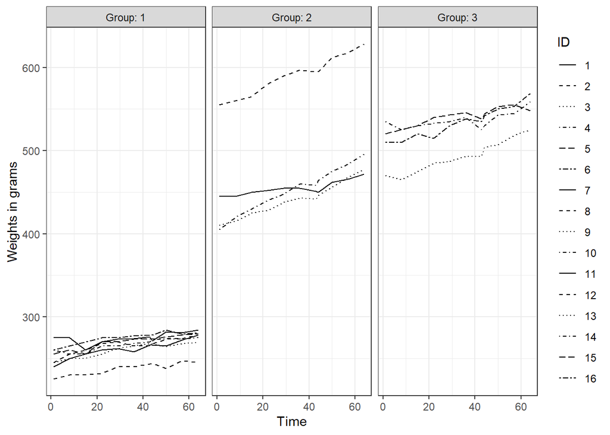

```r
#other data examinations are done above (and in the separate R script).

#First, let's plot the weight values of all 16 rats, differentiating between the three groups.

ggplot(RATS_l, aes(x = Time, y = Weight, linetype = ID)) +
  geom_line() +
  scale_linetype_manual(values = rep(1:10, times=4)) +
  facet_grid(. ~ Group, labeller = label_both) +
  theme(legend.position = "none") +
  scale_y_continuous(name = "Weights in grams", limits = c(min(RATS_l$Weight), max(RATS_l$Weight))) + theme_bw()
```

```r
# Next, let's make the same plot but with standardized weight values.

#standardizing weight measures, i.e., subtracting the relevant occasion mean from the original observation and divide it with the corresponding standard deviation.

RATS_ls <- RATS_l %>%
  group_by(Time) %>%
  mutate(std_Weight = (Weight - mean(Weight))/sd(Weight)) %>%
  ungroup()

glimpse(RATS_ls) #looks ok.
```

```
## Rows: 176
## Columns: 6
## $ ID         <fct> 1, 2, 3, 4, 5, 6, 7, 8, 9, 10, 11, 12, 13, 14, 15, 16, 1...
## $ Group      <fct> 1, 1, 1, 1, 1, 1, 1, 1, 2, 2, 2, 2, 3, 3, 3, 3, 1, 1, 1,...
## $ WD         <chr> "WD1", "WD1", "WD1", "WD1", "WD1", "WD1", "WD1", "WD1", ...
## $ Weight     <int> 240, 225, 245, 260, 255, 260, 275, 245, 410, 405, 445, 5...
## $ Time       <int> 1, 1, 1, 1, 1, 1, 1, 1, 1, 1, 1, 1, 1, 1, 1, 1, 8, 8, 8,...
## $ std_Weight <dbl> -1.0011429, -1.1203857, -0.9613953, -0.8421525, -0.88190...
```

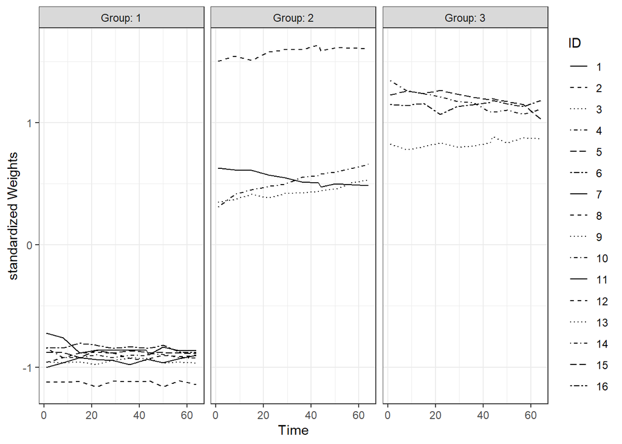

```r
# Plotting the standardized weights per group
ggplot(RATS_ls, aes(x = Time, y = std_Weight, linetype = ID)) +
  geom_line() +
  scale_linetype_manual(values = rep(1:10, times=4)) +
  facet_grid(. ~ Group, labeller = label_both) +
  scale_y_continuous(name = "standardized Weights") + theme_bw()
```

```r
#
```